# Bank Churn Prediction Neural Network

*Given a bank customer, build a neural network-based classifier that can determine whether they will leave or nothing in the next 6 months.*

```python
import numpy as np
import pandas as pd
import seaborn as sns
import matplotlib.pyplot as plt

%matplotlib inline
```

```python
data = pd.read_csv('bank.csv')
data.head()
```

|  | RowNumber | CustomerId | Surname | CreditScore | Geography | Gender | Age | Tenure | Balance | NumOfProducts | HasCrCard | IsActiveMember | EstimatedSalary | Exited |
| --- | --- | --- | --- | --- | --- | --- | --- | --- | --- | --- | --- | --- | --- | --- |
| 0 | 1 | 15634602 | Hargrave | 619 | France | Female | 42 | 2 | 0.00 | 1 | 1 | 1 | 101348.88 | 1 |
| 1 | 2 | 15647311 | Hill | 608 | Spain | Female | 41 | 1 | 83807.86 | 1 | 0 | 1 | 112542.58 | 0 |
| 2 | 3 | 15619304 | Onio | 502 | France | Female | 42 | 8 | 159660.80 | 3 | 1 | 0 | 113931.57 | 1 |
| 3 | 4 | 15701354 | Boni | 699 | France | Female | 39 | 1 | 0.00 | 2 | 0 | 0 | 93826.63 | 0 |
| 4 | 5 | 15737888 | Mitchell | 850 | Spain | Female | 43 | 2 | 125510.82 | 1 | 1 | 1 | 79084.10 | 0 |

### Feature Elimination

*Drop columns that are unique for all users, 5pts*

```python
data = data.drop(['RowNumber','CustomerId','Surname'], axis=1)
```

```python
data.head()
```

|  | CreditScore | Geography | Gender | Age | Tenure | Balance | NumOfProducts | HasCrCard | IsActiveMember | EstimatedSalary | Exited |
| --- | --- | --- | --- | --- | --- | --- | --- | --- | --- | --- | --- |
| 0 | 619 | France | Female | 42 | 2 | 0.00 | 1 | 1 | 1 | 101348.88 | 1 |
| 1 | 608 | Spain | Female | 41 | 1 | 83807.86 | 1 | 0 | 1 | 112542.58 | 0 |
| 2 | 502 | France | Female | 42 | 8 | 159660.80 | 3 | 1 | 0 | 113931.57 | 1 |
| 3 | 699 | France | Female | 39 | 1 | 0.00 | 2 | 0 | 0 | 93826.63 | 0 |
| 4 | 850 | Spain | Female | 43 | 2 | 125510.82 | 1 | 1 | 1 | 79084.10 | 0 |

*We don't drop two unique columns, `Balance` and `EstimatedSalary` because they may be relevant to churn.*

### Bivariate

*Bivariate analysis and insights, 5pts*

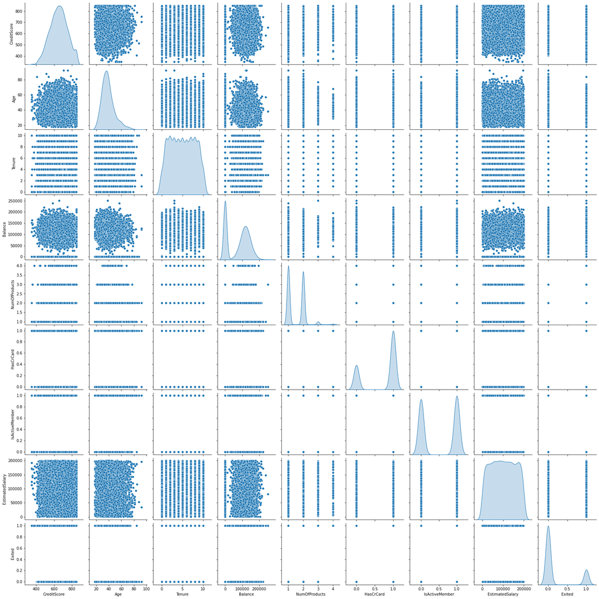

```python
sns.pairplot(data, diag_kind='kde');
```

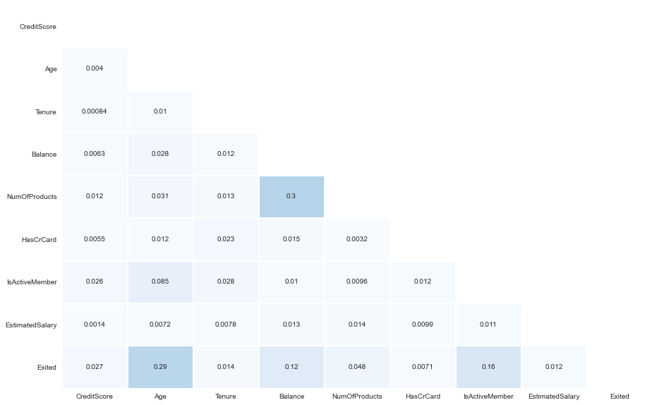

```python
correlation = abs(data.corr())
lower_triangle = np.tril(correlation, k=-1)
mask = lower_triangle == 0

plt.figure(figsize=(15,10))
sns.set_style(style='white')
sns.heatmap(lower_triangle, center=.5, cmap='Blues', annot=True,
            xticklabels=correlation.index, yticklabels=correlation.columns,
            cbar=False, linewidths=1, mask=mask)
plt.show();
```

#### Insights

There is very little *linear* correlation between individual properties. The biggest correlations are between `Balance` and `NumOfProducts`, and between `Age` and `Exited`, but even these correlations are low. This doesn't mean there is no correlation, only that it is not linear. Good dataset for a neural network.

### Data Split

*Distinguish feature and target sets; divide data into training and test sets, 5pts*

First thing's first, encode the categorical columns.

```python
data.head()
```

|  | CreditScore | Geography | Gender | Age | Tenure | Balance | NumOfProducts | HasCrCard | IsActiveMember | EstimatedSalary | Exited |
| --- | --- | --- | --- | --- | --- | --- | --- | --- | --- | --- | --- |
| 0 | 619 | France | Female | 42 | 2 | 0.00 | 1 | 1 | 1 | 101348.88 | 1 |
| 1 | 608 | Spain | Female | 41 | 1 | 83807.86 | 1 | 0 | 1 | 112542.58 | 0 |
| 2 | 502 | France | Female | 42 | 8 | 159660.80 | 3 | 1 | 0 | 113931.57 | 1 |
| 3 | 699 | France | Female | 39 | 1 | 0.00 | 2 | 0 | 0 | 93826.63 | 0 |
| 4 | 850 | Spain | Female | 43 | 2 | 125510.82 | 1 | 1 | 1 | 79084.10 | 0 |

```python
data = pd.get_dummies(data, columns=['Geography','Gender'])
data.head()
```

|  | CreditScore | Age | Tenure | Balance | NumOfProducts | HasCrCard | IsActiveMember | EstimatedSalary | Exited | Geography_France | Geography_Germany | Geography_Spain | Gender_Female | Gender_Male |
| --- | --- | --- | --- | --- | --- | --- | --- | --- | --- | --- | --- | --- | --- | --- |
| 0 | 619 | 42 | 2 | 0.00 | 1 | 1 | 1 | 101348.88 | 1 | 1 | 0 | 0 | 1 | 0 |
| 1 | 608 | 41 | 1 | 83807.86 | 1 | 0 | 1 | 112542.58 | 0 | 0 | 0 | 1 | 1 | 0 |
| 2 | 502 | 42 | 8 | 159660.80 | 3 | 1 | 0 | 113931.57 | 1 | 1 | 0 | 0 | 1 | 0 |
| 3 | 699 | 39 | 1 | 0.00 | 2 | 0 | 0 | 93826.63 | 0 | 1 | 0 | 0 | 1 | 0 |
| 4 | 850 | 43 | 2 | 125510.82 | 1 | 1 | 1 | 79084.10 | 0 | 0 | 0 | 1 | 1 | 0 |

```python
from sklearn.model_selection import train_test_split

x = data.drop('Exited', axis=1)
y = data['Exited']
```

```python
x_train, x_test, y_train, y_test = train_test_split(x, y, test_size=.3, random_state=42)

x_train.head()
```

|  | CreditScore | Age | Tenure | Balance | NumOfProducts | HasCrCard | IsActiveMember | EstimatedSalary | Geography_France | Geography_Germany | Geography_Spain | Gender_Female | Gender_Male |
| --- | --- | --- | --- | --- | --- | --- | --- | --- | --- | --- | --- | --- | --- |
| 9069 | 619 | 32 | 4 | 175406.13 | 2 | 1 | 1 | 172792.43 | 0 | 0 | 1 | 1 | 0 |
| 2603 | 643 | 34 | 7 | 160426.07 | 1 | 0 | 1 | 188533.11 | 0 | 1 | 0 | 1 | 0 |
| 7738 | 561 | 33 | 6 | 0.00 | 2 | 0 | 0 | 173680.39 | 1 | 0 | 0 | 0 | 1 |
| 1579 | 618 | 41 | 8 | 37702.79 | 1 | 1 | 1 | 195775.48 | 0 | 1 | 0 | 0 | 1 |
| 5058 | 714 | 37 | 9 | 148466.93 | 2 | 0 | 1 | 151280.96 | 1 | 0 | 0 | 0 | 1 |

```python
print('{0:0.2f}% of data in training set'.format((len(x_train)/len(data.index))*100))
print('{0:0.2f}% of data in test set'.format((len(x_test)/len(data.index))*100))
```

```
70.00% of data in training set
30.00% of data in test set
```

```python
print('Churned customers in full dataset:     {0} ({1:0.2f}%)'.format(len(data.loc[data['Exited']==1]), (len(data.loc[data['Exited']==1])/len(data.index))*100))
print('Churned customers in full dataset:     {0} ({1:0.2f}%)'.format(len(data.loc[data['Exited']==0]), (len(data.loc[data['Exited']==0])/len(data.index))*100))
print('')
print('Churned customers in training dataset: {0} ({1:0.2f}%)'.format(len(y_train[y_train[:]==1]), (len(y_train[y_train[:] == 1])/len(y_train)) * 100))
print('Churned customers in training dataset: {0} ({1:0.2f}%)'.format(len(y_train[y_train[:]==0]), (len(y_train[y_train[:] == 0])/len(y_train)) * 100))
print('')
print('Churned customers in test dataset:     {0} ({1:0.2f}%)'.format(len(y_test[y_test[:]==1]), (len(y_test[y_test[:] == 1])/len(y_test)) * 100))
print('Churned customers in test dataset:     {0} ({1:0.2f}%)'.format(len(y_test[y_test[:]==0]), (len(y_test[y_test[:] == 0])/len(y_test)) * 100))
```

```
Churned customers in full dataset:     2037 (20.37%)
Churned customers in full dataset:     7963 (79.63%)

Churned customers in training dataset: 1453 (20.76%)
Churned customers in training dataset: 5547 (79.24%)

Churned customers in test dataset:     584 (19.47%)
Churned customers in test dataset:     2416 (80.53%)
```

### Normalization

*Normalize train and test data, 10pts*

```python
# We can remove one of each of our one-hot encoded columns
x_train = x_train.drop(['Geography_France', 'Gender_Female'], axis=1)
x_test = x_test.drop(['Geography_France', 'Gender_Female'], axis=1)
```

```python
from scipy.stats import zscore

scaled = data.apply(zscore)
x_train = x_train.apply(zscore)
x_test = x_test.apply(zscore)
```

```python
x_train.head()
```

|  | CreditScore | Age | Tenure | Balance | NumOfProducts | HasCrCard | IsActiveMember | EstimatedSalary | Geography_Germany | Geography_Spain | Gender_Male |
| --- | --- | --- | --- | --- | --- | --- | --- | --- | --- | --- | --- |
| 9069 | -0.344595 | -0.656750 | -0.342170 | 1.583725 | 0.819663 | 0.645981 | 0.970714 | 1.248214 | -0.575591 | 1.730732 | -1.098232 |
| 2603 | -0.095181 | -0.466380 | 0.698162 | 1.344106 | -0.903352 | -1.548034 | 0.970714 | 1.521225 | 1.737346 | -0.577790 | -1.098232 |
| 7738 | -0.947345 | -0.561565 | 0.351385 | -1.222055 | 0.819663 | -1.548034 | -1.030169 | 1.263615 | -0.575591 | -0.577790 | 0.910554 |
| 1579 | -0.354987 | 0.199916 | 1.044940 | -0.618965 | -0.903352 | 0.645981 | 0.970714 | 1.646839 | 1.737346 | -0.577790 | 0.910554 |
| 5058 | 0.642668 | -0.180824 | 1.391718 | 1.152808 | 0.819663 | -1.548034 | 0.970714 | 0.875112 | -0.575591 | -0.577790 | 0.910554 |

### Modelling

*Initialize and build the model; identify points of improvement and implement, 20pts*

```python
from tensorflow import keras
from tensorflow.keras import Sequential
from tensorflow.keras.layers import Dense
from tensorflow.keras.optimizers import SGD
```

```python
keras.backend.set_floatx('float64')

model = Sequential()

opt = SGD(lr=.005, momentum=.9)

# 11-node input layer and 9-node hidden layer
model.add(Dense(9, input_shape=(11,), activation='elu'))

# Single output neuron
model.add(Dense(1, activation='sigmoid'))

model.compile(loss='binary_crossentropy', optimizer=opt, metrics=['accuracy'])

history = model.fit(x_train, y_train, epochs=2500, batch_size=4096, verbose=0, validation_data=(x_test, y_test))
```

```
Training Accuracy: 0.857
Testing Accuracy: 0.866

Training Loss: 0.344
Testing Loss: 0.338
```

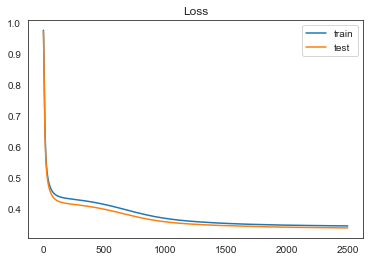

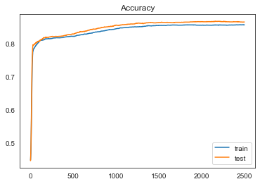

```python
train_loss, train_acc = model.evaluate(x_train, y_train, verbose=0)
test_loss, test_acc = model.evaluate(x_test, y_test, verbose=0)

print('Training Accuracy: %.3f' % train_acc)
print('Testing Accuracy: %.3f' % test_acc)
print('')
print('Training Loss: %.3f' % train_loss)
print('Testing Loss: %.3f' % test_loss)

plt.title('Loss')
plt.plot(history.history['loss'], label='train')
plt.plot(history.history['val_loss'], label='test')
plt.legend()
plt.show()

plt.title('Accuracy')
plt.plot(history.history['accuracy'], label='train')
plt.plot(history.history['val_accuracy'], label='test')
plt.legend()
plt.show()
```

### Prediction

*Predict the results using 0.5 as a threshold, 10pts*

```python
y_predict = model.predict(x_test)
```

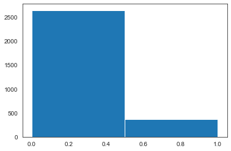

```python
plt.hist(y_predict, bins=[0, .5, 1]);
```

```python
x_pred = x_test.copy()

x_pred['Prediction'] = x_pred.apply(lambda _: '', axis=1)

for i in range(0,3000):
    x_pred.iloc[i, -1] = 1 if y_predict[i][0] > 0.5 else 0

x_pred.head(10)
```

|  | CreditScore | Age | Tenure | Balance | NumOfProducts | HasCrCard | IsActiveMember | EstimatedSalary | Geography_Germany | Geography_Spain | Gender_Male | Prediction |
| --- | --- | --- | --- | --- | --- | --- | --- | --- | --- | --- | --- | --- |
| 6252 | -0.520142 | -0.667710 | -0.712482 | 0.322306 | 0.780431 | -1.547147 | -1.031840 | -0.990581 | 1.706266 | -0.564519 | 0.916783 | 0 |
| 4684 | -0.243282 | 0.385561 | -1.399654 | -1.234784 | 0.780431 | 0.646351 | 0.969143 | 0.840374 | -0.586075 | -0.564519 | 0.916783 | 0 |
| 1731 | -0.468871 | 0.481313 | -0.368896 | -1.234784 | 0.780431 | 0.646351 | -1.031840 | -0.696956 | -0.586075 | 1.771421 | -1.090771 | 0 |
| 4742 | -1.443009 | 1.917592 | 1.005446 | 0.683655 | 0.780431 | 0.646351 | 0.969143 | 1.265774 | 1.706266 | -0.564519 | 0.916783 | 0 |
| 4521 | -0.889289 | -1.146469 | 0.661861 | 0.777746 | -0.931041 | 0.646351 | 0.969143 | 0.285271 | -0.586075 | 1.771421 | -1.090771 | 0 |
| 6340 | 1.469150 | -0.188950 | 1.005446 | -1.234784 | 0.780431 | 0.646351 | 0.969143 | 0.893576 | -0.586075 | 1.771421 | 0.916783 | 0 |
| 576 | -2.130033 | -0.667710 | -0.712482 | 1.001638 | -0.931041 | 0.646351 | -1.031840 | -0.397174 | -0.586075 | 1.771421 | -1.090771 | 0 |
| 5202 | -0.509888 | -1.625229 | 0.318275 | 0.399904 | -0.931041 | 0.646351 | -1.031840 | -0.487452 | 1.706266 | -0.564519 | -1.090771 | 0 |
| 6363 | 0.320693 | 0.098305 | -0.368896 | 0.597390 | -0.931041 | 0.646351 | -1.031840 | -1.431197 | -0.586075 | 1.771421 | -1.090771 | 0 |
| 439 | -1.873681 | 0.289809 | -0.712482 | 0.144717 | -0.931041 | 0.646351 | 0.969143 | 1.150673 | 1.706266 | -0.564519 | -1.090771 | 1 |

See confusion matrix breakdown for actual counts

### Model Performance Evaluation

*Print accuracy score and confusion matrix, 5pts*

[output not shown]

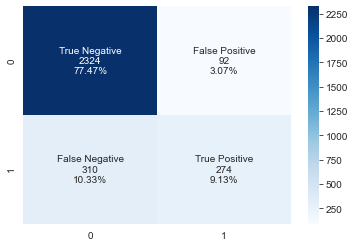

```python
from sklearn.metrics import accuracy_score, confusion_matrix, precision_score, recall_score, f1_score

y_pred_cls = model.predict_classes(x_test, batch_size=200, verbose=0)

print('Accuracy: ' + str(model.evaluate(x_test, y_test.values)[1]))
print('Recall: ' + str(recall_score(y_test.values, y_pred_cls)))
print('Precision score: ' + str(precision_score(y_test.values, y_pred_cls)))
print('F-score: ' + str(f1_score(y_test.values, y_pred_cls)))

cm = confusion_matrix(y_test.values, y_pred_cls)

group_names = ['True Negative',
               'False Positive',
               'False Negative',
               'True Positive']

group_counts = ["{0:0.0f}".format(value) for value in cm.flatten()]
group_percs = ["{0:.2%}".format(value) for value in cm.flatten()/np.sum(cm)]

labels = [f"{v1}\n{v2}\n{v3}" for v1, v2, v3 in zip(group_names, group_counts, group_percs)]
labels = np.asarray(labels).reshape(2,2)

sns.heatmap(cm, annot=labels, fmt='', cmap='Blues');
```

With successful outreach to customers identified as at-risk by this model, churn could be reduced by up to 46%.